Activty recognition from single chest mounted accelerometer

David Janda

11 11 2020

Abstaract

Introduction

Main goal of this data science project is to build at least two machine learning algorithms for Activity

recognition from single chest mounted accelerometer data. Target accuracy of best performing algorithm is

95 % or more. The data set is acquired through UCI machine learning repository. The data consist of 1 ﬁle

per user with 15 users total. Each ﬁle contains data for triaxial accelerometer, sequential number and user

id.

Methods

The data from each user are combined together to make one dataset. The set is then cleaned and separated

into data and validation (unseen) set. Data exploration is done through written or visualized form. For

visualization are used various packages.

There are three algorithms build - decision tree, random forest and k-nearest neighbors. After is the algorithm

build it’s then ﬁt into the validation set.

Results

The best results were acquired by Random forest algorithm with accuracy of 98 %. For this approach was

used Ranger package with auto tuning parameters.

Conclusion

Our task was to build machine learning algorithm for human activity recognition. It was done by three

diﬀerent approaches. And best accuracy was acquired by random forest algorithm. The results could be

improved by setting diﬀerent algorithms together like kNN + Rf. Or by using neural network or deep learning

techniques.

Limitations of this work could be limited knowledge of accelerometers used for data measurement, therefore

the algorithm wouldn’t have to work on diﬀerent data set.

1

Introduction

Human activity recognition also called HAR is getting a lot of attention since it’s inception. And this ﬁeld

is still evolving. The knowledge of user’s activity can help to personalize services, improve health care and

study human behavior such as in sociology or physical activity science. Since nowadays there were many

sensor based devices used to monitor human activity. Such as heart rate monitors, GPS or accelerometers.

From the heart rate monitors and GPS signals we can only roughly determine what kind of activity is person

doing and we have to contextualize it with environment in which is the activity done. Or use other devices

that can help us to understand the persons movement. One of these devices are accelerometers, which is

an electromechanical device used to measure acceleration forces. The force may be static, like gravitational

or dynamic, like human movement. The accelerometers that are used for monitoring humans movement are

usually small devices, that can be attached for example to wrist, waist or chest. However there are also

accelerometers in smart phones and their signal can also be used for activity recognition. The device can

measure the activity in diﬀerent axis, nowadays is the standard to measure in triaxial dimension - x, y, z.

The signal is then stored in device and can be downloaded a transformed into csv. ﬁle format. However

for human activity recognition we need some base data that are labeled with speciﬁc activity so we can use

them to train algorithms. Therefore for our purpose we will use data from UC Irvine Machine Learning

Repository.

Dataset

We will use data provided for Activity recognition from single chest mounted accelerometer, the

data are obtained from this website: http://archive.ics.uci.edu/ml/datasets/Activity+Recognition+from+

Single+Chest-Mounted+Accelerometer# Downloaded folder consist data from 15 participants, one .csv ﬁle

per person, with label of activity type. Activities performed are: 1. Working at Computer

2. Standing Up, Walking and Going updown stairs

3. Standing

4. Walking

5. Going UpDown Stairs

6. Walking and Talking with Someone

7. Talking while Standing

The labels are codiﬁed as numbers. The data of three axes are recorded on sampling frequency of 52 Hz and

are uncalibrated. The data set also contains sequential number.

Goals of this project

This project is last step in HarvardX PH125.9x Data Science professional certiﬁcate and part of Capstone

course. Aim of this project is to build at least two machine learning algorithms that will predict human

activity based on input from triaxial accelerometer. The results will be tested on generated validation set.

Performance of the algorithm will be evaluated by accuracy. Personal goal is to have accuracy better than

95 %.

Steps toward the goal

• Introduction

• Data downloading and cleaning

• Description of dataset

• Exploration analysis

• Building algorithm for activity prediction

• Activity prediction

• Summarize and give recommendations for future work

2

[figure not shown]

Methods

Preparation of work space

First we load necessary packages that are going to be used, if they are not installed we will install them:

# install packages if they are not installed

if (!require(tidyverse)) install.packages("tidyverse", repos = "http://cran.us.r-project.org")

if (!require(caret)) install.packages("caret", repos = "http://cran.us.r-project.org")

if (!require(data.table)) install.packages("data.table", repos = "http://cran.us.r-project.org")

if (!require(knitr)) install.packages("knitr", repos = "http://cran.us.r-project.org")

if (!require(ggridges)) install.packages("ggridges", repos = "http://cran.us.r-project.org")

if (!require(ggplot2)) install.packages("ggplot2", repos = "http://cran.us.r-project.org")

if (!require(e1071)) install.packages("e1071", dependencies = TRUE, repos = "http://cran.us.r-project.org")

if (!require(stats)) install.packages("stats", repos = "http://cran.us.r-project.org")

if (!require(gridExtra)) install.packages("gridExtra", repos = "http://cran.us.r-project.org")

if (!require(ranger)) install.packages("ranger", repos = "http://cran.us.r-project.org")

if (!require(tuneRanger)) install.packages("tuneRanger", repos = "http://cran.us.r-project.org")

if (!require(forecast)) install.packages("forecast", dependencies = TRUE, repos = "http://cran.us.r-project.org")

if (!require(doParallel)) install.packages("doParallel", repos = "http://cran.us.r-project.org")

# Load them if not loaded

if (!require(tidyverse)) library("tidyvers")

if (!require(caret)) library("caret")

if (!require(data.table)) library("data.table")

if (!require(knitr)) library("knitr")

if (!require(ggridges)) library("ggridges")

if (!require(ggplot2)) library("ggplot2")

if (!require(e1071)) library("e1071")

if (!require(stats)) library("stats")

if (!require(gridExtra)) library("gridExtra")

if (!require(ranger)) library("stats")

if (!require(tuneRanger)) library("stats")

if (!require(forecast)) library("forecast")

if (!require(doParallel)) library("forecast")

Then we can download our data from https://archive.ics.uci.edu/ml/datasets/Activity+Recognition+from+

Single+Chest-Mounted+Accelerometer#. We download the zipped ﬁle into temporary object.

As the data were downloaded in separated ﬁles per user we will merge them into one dataset.Also it has

theme so the values are on the same scale. We will also change the sequential number so the activities can

be displayed next to each other. Then we create new value named vector magnitude which represents length

of vector for our three axis.

In the dataset was found activity category 0 which is not described, so we delete it. Also we give meaningful

labels to activities.

# Crating one data frame

AR <- bind_rows(list(AR1, AR2, AR3, AR4, AR5, AR6, AR7, AR8, AR9, AR10, AR11, AR12, AR13, AR14, AR15), .id = "id" )

# Adjustment of data

## Giving meaningful label to activities

## Also delete activity = 0, because there wasn’t specification about this type

3

[figure not shown]

AR$activity <- factor(AR$activity,

levels = c(1,2,3,4,5,6,7),

labels = c("working", "stand_walk_down",

"standing", "walking",

"going_up_down", "walk+talk", "stand+talk"))

# Creating normalization function

normalize <- function(x){

return(x - min(x)) / (max(x) - min(x))

}

## Creating vector magnitude, applying median filter to remove outlines, normalizing data

## Creating sequential number for each activity

AR <- AR %>%

mutate(id = as.numeric(id),

vm = sqrt(x^2 + y^2 + z^2),

x = runmed(x, k = 5),

y = runmed(y, k = 5),

z = runmed(z, k = 5)) %>%

group_by(activity) %>%

mutate(seq = as.numeric(1:n()),

x = normalize(x),

y = normalize(y),

z = normalize(z),

vm = normalize(vm)) %>%

subset(activity != 0)

As last step of our preparation we split the data into part that we will use for visualization and algorithm

building and part for validation of our algorithm.

The splitting is done 70/30 to have major part of the data for manipulation.

4

[figure not shown]

Data analysis

Dataset

To know with what kind of data are we dealing with we will now display some describing parameters.

Let’s start with dimensions. Number of rows and column.

## [1] 1346222 7

As we can see the data has 7 columns, each for one variable and a lot of rows.

It’s understandable because it’s signal with frequency of 52 Hz. For more details we display ﬁrst 6 rows.

## # A tibble: 6 x 7

## id seq x y z activity vm

## <dbl> <dbl> <dbl> <dbl> <dbl> <fct> <dbl>

## 1 1 2 968 1687 2038 working 1945.

## 2 1 3 968 1580 1897 working 1761.

## 3 1 4 968 1574 1897 working 1700.

## 4 1 5 968 1572 1897 working 1766.

## 5 1 8 961 1574 1912 working 1732.

## 6 1 9 964 1593 1931 working 1786.

The signal is not much understandable if we don’t know it’s composition.

Lets see what kind of values do we have on each axes and other variables with summary() and str() function:

# Summary of data

data %>% summary()

## id seq x y

## Min. : 1.000 Min. : 1 Min. : 0.0 Min. : 0.0

## 1st Qu.: 4.000 1st Qu.: 83474 1st Qu.: 388.0 1st Qu.: 463.0

## Median : 7.000 Median :203603 Median : 534.0 Median : 633.0

## Mean : 7.513 Mean :235203 Mean : 724.2 Mean : 990.8

## 3rd Qu.:11.000 3rd Qu.:360927 3rd Qu.:1248.0 3rd Qu.:1949.0

## Max. :15.000 Max. :608667 Max. :2886.0 Max. :3709.0

##

## z activity vm

## Min. : 0.0 working :426154 Min. : 0.0

## 1st Qu.: 360.0 stand_walk_down: 33550 1st Qu.: 668.5

## Median : 442.0 standing :152078 Median : 790.6

## Mean : 882.5 walking :249838 Mean :1189.1

## 3rd Qu.:1846.0 going_up_down : 36035 3rd Qu.:2157.0

## Max. :4084.0 walk+talk : 33305 Max. :4625.1

## stand+talk :415262

# Structure of data

data %>% str()

## tibble [1,346,222 x 7] (S3: grouped_df/tbl_df/tbl/data.frame)

## $ id : num [1:1346222] 1 1 1 1 1 1 1 1 1 1 ...

## $ seq : num [1:1346222] 2 3 4 5 8 9 10 11 12 13 ...

## $ x : num [1:1346222] 968 968 968 968 961 964 953 947 953 953 ...

5

[figure not shown]

## $ y : num [1:1346222] 1687 1580 1574 1572 1574 ...

## $ z : num [1:1346222] 2038 1897 1897 1897 1912 ...

## $ activity: Factor w/ 7 levels "working","stand_walk_down",..: 1 1 1 1 1 1 1 1 1 1 ...

## $ vm : num [1:1346222] 1945 1761 1700 1766 1732 ...

## - attr(*, "groups")= tibble [7 x 2] (S3: tbl_df/tbl/data.frame)

## ..$ activity: Factor w/ 7 levels "working","stand_walk_down",..: 1 2 3 4 5 6 7

## ..$ .rows : list<int> [1:7]

## .. ..$ : int [1:426154] 1 2 3 4 5 6 7 8 9 10 ...

## .. ..$ : int [1:33550] 23496 23497 23498 23499 23500 23501 23502 23503 23504 23505 ...

## .. ..$ : int [1:152078] 24152 24153 24154 24155 24156 24157 24158 24159 24160 24161 ...

## .. ..$ : int [1:249838] 26877 26878 26879 26880 26881 26882 26883 26884 26885 26886 ...

## .. ..$ : int [1:36035] 48614 48615 48616 48617 48618 48619 48620 48621 48622 48623 ...

## .. ..$ : int [1:33305] 52950 52951 52952 52953 52954 52955 52956 52957 52958 52959 ...

## .. ..$ : int [1:415262] 54987 54988 54989 54990 54991 54992 54993 54994 54995 54996 ...

## .. ..@ ptype: int(0)

## ..- attr(*, ".drop")= logi TRUE

For our analysis we need clear dataset without missing values so we check also this:

# Missing values check

sum(is.na(data))

## [1] 0

sum(is.na(validation))

## [1] 0

Now we know with what kind of data are we working. So we can go on and explore each activity signal.

6

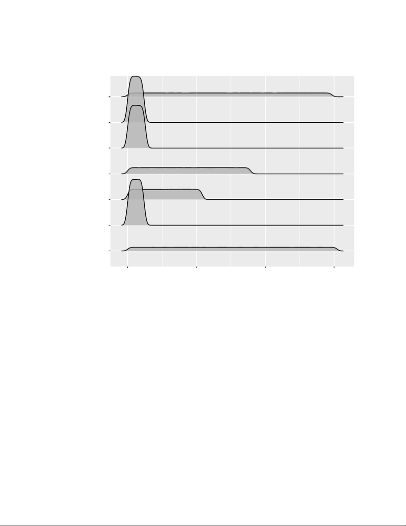

Activities

We know there are 7 activities with labels to diﬀer them. We will start with plotting their length:

working

stand_walk_down

standing

walking

going_up_down

walk+talk

stand+talk

0e+00 2e+05 4e+05 6e+05

Time sequence

Activity

As we can see the activities have diﬀerent duration, however it shouldn’t aﬀect our analysis.

We will now plot signal per activity in smaller time window so we can see if there is any pattern to recognize.

7

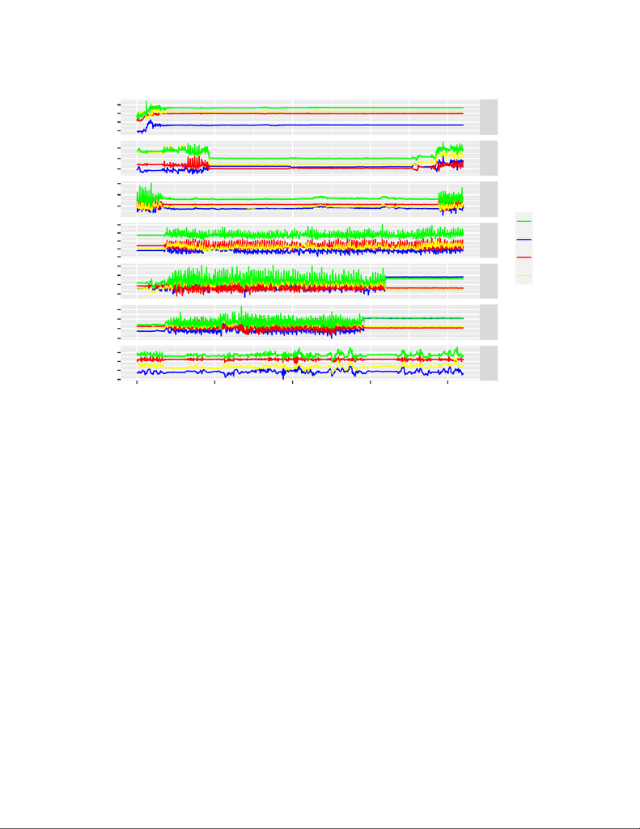

working

stand_walk_down

standing

walking

going_up_down

walk+talk

stand+talk

0 1,000 2,000 3,000 4,000

1000

1500

2000

2500

250

500

750

400

600

800

200

400

600

800

1000

200

400

600

800

0

200

400

600

200

400

600

800

Time sequence

X

Y

Z

VM

Activities per axes

As we can see the diﬀerence in patterns is quiet visible. For example in walking we can see the waving of

curve because of the steps, the same goes for going up or down, walking + talking and stand + walk down.

On the other hand the static activities as working or standing seems to have more straight line signal. Also

we can see there is diﬀerence in strength of the signal.

From this graph we can see that it shouldn’t be hard to recognize the activity. For example the signal of

working is much more stable but stronger, the standing is also quiet static but the signal is low. On the

other hand walking has quiet visible pattern of signal that diﬀers to going up or down or other activities.

8

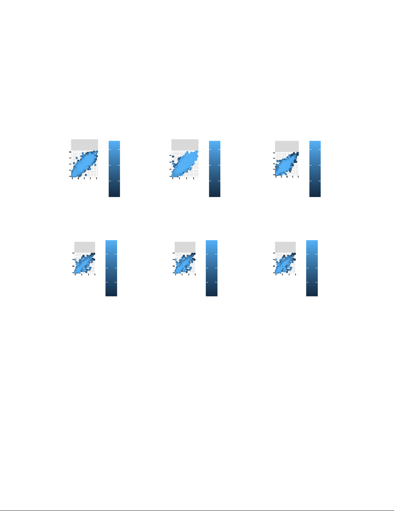

Lag plots

At last we will use lag plots to conﬁrm correlation of signal per activity and also to evaluate whether

the values of our data are random. If the data are random, the lag plot will exhibit no identiﬁable

pattern. If the data are not random, the lag plot will demonstrate a clearly identiﬁable pattern. And

as we can see our data display linear pattern with autocorellation that follow the diagonal. We have

divided the activities by their pattern of static or dynamic position for better understanding the data.

lag 1

0200400600800

0

200

400

600

800

1e+05

2e+05

3e+05

Time

X Dynamic

lag 1

0300600900

0

300

600

900

1e+05

2e+05

3e+05

Time

Y Dynamic

lag 1

02505007501000

0

250

500

750

1000

1e+05

2e+05

3e+05

Time

Z Dynamic

lag 1

0100020003000

0

1000

2000

3000

250000

500000

750000

Time

X Static

lag 1

0100020003000

0

1000

2000

3000

250000

500000

750000

Time

y Static

lag 1

0100020003000

0

1000

2000

3000

250000

500000

750000

Time

Z Static

Lag plot

As we know now the data are correlated in both cases and displays pattern of signal. We can now move on

and start to build our algorithm.

9

[figure not shown]

Algorithm building

Starting with data partition as our preparation for algorithm building. We divide the data to 60 % of train

set and 40 % of test set. We do so, to reduce the amount of time required for computation. However even

after this reduction, the computation can take a lot of time (On my computer with processor AMD Ryzen

3600 with 16G RAM took the decision tree 0,5h, kNN 3-4h and Rf 40 minutes.)

We will build three algorithms. Starting with decision tree, following k-nearest neighbors (kNN) and last will

be random forest (Rf). For decision tree and kNN we use Caret package and for Rf we use ranger package

because of it’s ability to use most of the computational power. However to speed up the process with carate

package we will use the doParralel package that allows to separate the computation into multiple cores.

Decision tree

We start with decision tree because it’s fastest application and less demanding of computational power. A

decision tree is a ﬂowchart-like structure in which each internal node represents a “test” on an attribute

(e.g. whether a coin ﬂip comes up heads or tails), each branch represents the outcome of the test, and each

leaf node represents a class label (decision taken after computing all attributes). The paths from root to leaf

represent classiﬁcation rules. However we wont display the decision tree itself because of necessary “tests”

on attributes. It would take a lot of space to display all the branches.

later for kNN.

control <- trainControl(method = "cv", number = 10, p = .9)

### Using doParralel package to use more cores in computer (This is set to 10 because of 12 maximum)

### It’s gonna be used even for knn

cl <- makePSOCKcluster(10)

registerDoParallel(cl)

train_tree <- caret::train(activity ~ x + y + z + vm,

method = "rpart",

data = train_set,

tuneGrid = expand.grid(cp = seq(0.01, 0.1, 25)),

trControl = control)

Best performing value of complexity parameter is shown below. We ﬁt it into our model:

train_tree

## CART

##

## 807731 samples

## 4 predictor

## 7 classes: ’working’, ’stand_walk_down’, ’standing’, ’walking’, ’going_up_down’, ’walk+talk’, ’stand+talk’

##

## No pre-processing

## Resampling: Cross-Validated (10 fold)

## Summary of sample sizes: 726958, 726960, 726958, 726957, 726959, 726959, ...

## Resampling results:

##

## Accuracy Kappa

10

[figure not shown]

## 0.8803228 0.8401133

##

## Tuning parameter ’cp’ was held constant at a value of 0.01

fit_tree <- caret::train(activity ~ x + y + z + vm,

method = "rpart",

data = train_set,

tuneGrid = data.frame(cp = train_tree$bestTune),

trControl = control)

The accuracy of regression tree is:

acc_tree <- confusionMatrix(caret::predict.train(fit_tree, test_set),

test_set$activity)$overall["Accuracy"]

acc_tree

## Accuracy

## 0.8801744

That is quiet good but the performance can be deﬃnitely better with more complex model.

11

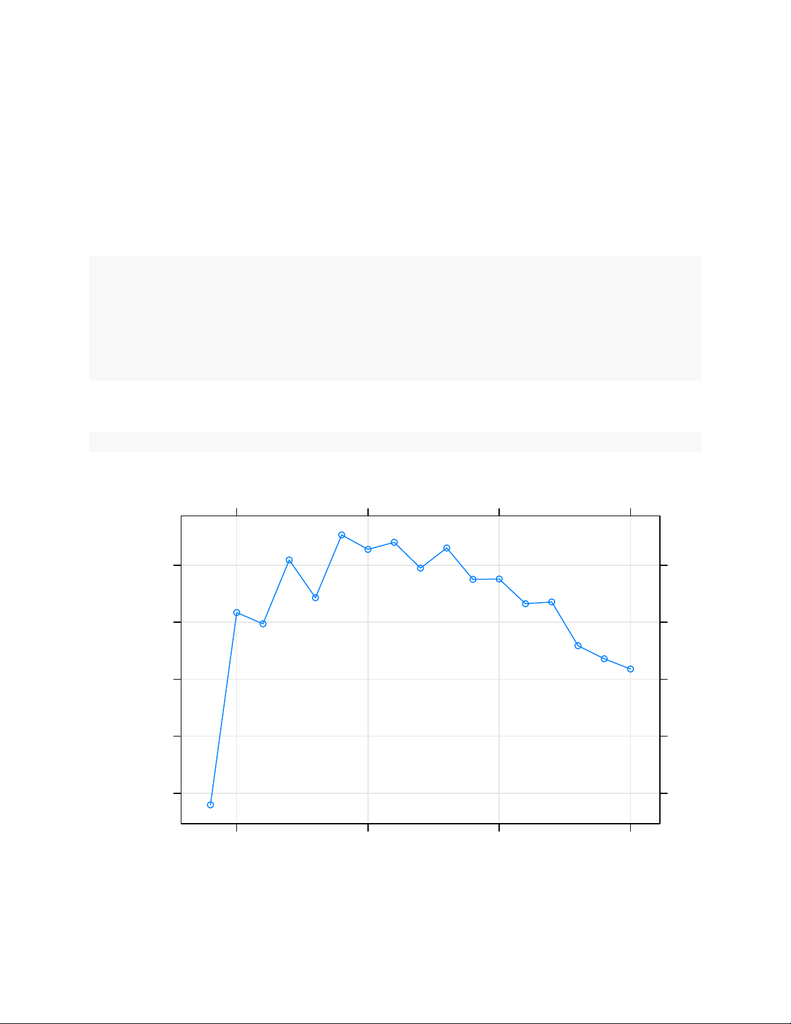

k-nearest neighbors

The kNN is a non-parametric method used for classiﬁcation and regression. The algorithm assumes that

similar things exist in close proximity. In other words, similar things are near to each other. It uses ‘feature

similarity’ to predict the values of new data points which further means that the new data point will be

We tune the model with K sequence and with cross validation. After we ﬁnd best K value we ﬁt it into our

model.

### Using doParralel from previous chunk

cl <- makePSOCKcluster(10)

registerDoParallel(cl)

train_knn <- caret::train(activity ~ x + y + z + vm, method = "knn",

data = train_set,

tuneGrid = data.frame(k = seq(4,20,1)),

trControl = control)

The plot of possible K values is displayed below. And we ﬁt the optimal one into our model.

plot(train_knn, highlight = TRUE)

#Neighbors

Accuracy (Cross−Validation)

0.9806

0.9808

0.9810

0.9812

0.9814

5 10 15 20

12

[figure not shown]

fit_knn <- caret::train(activity ~ x + y + z + vm, method = "knn",

data = train_set,

tuneGrid = data.frame(k = train_knn$bestTune),

trControl = control)

The accuracy of kNN with best tune k parameter is:

acc_knn <- confusionMatrix(caret::predict.train(fit_knn, test_set),

test_set$activity)$overall["Accuracy"]

acc_knn

## Accuracy

## 0.9814667

It performs really well, but lets try our last algorithm.

13

[figure not shown]

Random forest

Random forest is a classiﬁer that evolves from decision trees. It actually consists of many decision trees. To

classify a new instance, each decision tree provides a classiﬁcation for input data. It collects the classiﬁcations

and chooses the most voted prediction as the result.

The Ranger package provides auto tuning function so we will use it. Then we ﬁt the best parameters into

our model:

## Preparing our data = clearing

data_rf <- train_set %>% select(-id, -seq) %>% as.data.frame()

## Creating classification task that is needed for tuneRanger

data.task <- makeClassifTask(data = data_rf, target = "activity")

### Auto tuning withe tuneRanger function

tune_rf <- tuneRanger(data.task, measure = list(acc), num.trees = 150,

tune.parameters = c("mtry", "min.node.size", "sample.fraction"))

tune_rf

## Recommended parameter settings:

## mtry min.node.size sample.fraction

## 1 2 2 0.6657858

## Results:

## acc exec.time

## 1 0.9820767 46.224

## Fitting in the best values

fit_rf <- ranger(activity ~ x + y + z + vm, train_set,

num.trees = 150,

mtry = 2,

min.node.size = 2,

The accuracy of Rf is:

acc_rf <- confusionMatrix(as.factor(predict(fit_rf, test_set)$predictions),

test_set$activity)$overall["Accuracy"]

acc_rf

## Accuracy

## 0.982126

14

[figure not shown]

Results

The results of our algorithms are presented below:

method Accuracy

Decision tree 0.8801744

k-nearest neighbors algorithm 0.9814667

Random Forest 0.9821260

As we can see the Random forest and kNN performance is really good. But the Random Forest perform

little bit better. So we will predict the validation - unseen set, with our Random forrest model. You can see

the resulting confusion matrix on the next page:

15

[figure not shown]

predict <- predict(fit_rf, validation)

confusionMatrix(as.factor(predict$predictions), validation$activity)

## Confusion Matrix and Statistics

##

## Reference

## Prediction working stand_walk_down standing walking going_up_down

## working 182504 0 0 0 0

## stand_walk_down 0 13768 7 162 25

## standing 4 5 60817 47 3585

## walking 3 506 132 106836 72

## going_up_down 0 18 1608 20 11116

## walk+talk 0 11 65 60 54

## stand+talk 2 20 2030 101 611

## Reference

## Prediction walk+talk stand+talk

## working 0 0

## stand_walk_down 4 8

## standing 51 682

## walking 135 80

## going_up_down 25 130

## walk+talk 14231 6

## stand+talk 19 177395

##

## Overall Statistics

##

## Accuracy : 0.9822

## 95% CI : (0.9818, 0.9825)

## No Information Rate : 0.3163

## P-Value [Acc > NIR] : < 2.2e-16

##

## Kappa : 0.9764

##

## Mcnemar’s Test P-Value : NA

##

## Statistics by Class:

##

## Class: working Class: stand_walk_down Class: standing

## Sensitivity 1.0000 0.96092 0.9406

## Specificity 1.0000 0.99963 0.9915

## Pos Pred Value 1.0000 0.98526 0.9329

## Neg Pred Value 1.0000 0.99901 0.9925

## Prevalence 0.3163 0.02483 0.1121

## Detection Rate 0.3163 0.02386 0.1054

## Detection Prevalence 0.3163 0.02422 0.1130

## Balanced Accuracy 1.0000 0.98027 0.9660

## Class: walking Class: going_up_down Class: walk+talk

## Sensitivity 0.9964 0.71888 0.98382

## Specificity 0.9980 0.99679 0.99965

## Pos Pred Value 0.9914 0.86057 0.98641

## Neg Pred Value 0.9992 0.99229 0.99958

## Prevalence 0.1858 0.02680 0.02507

16

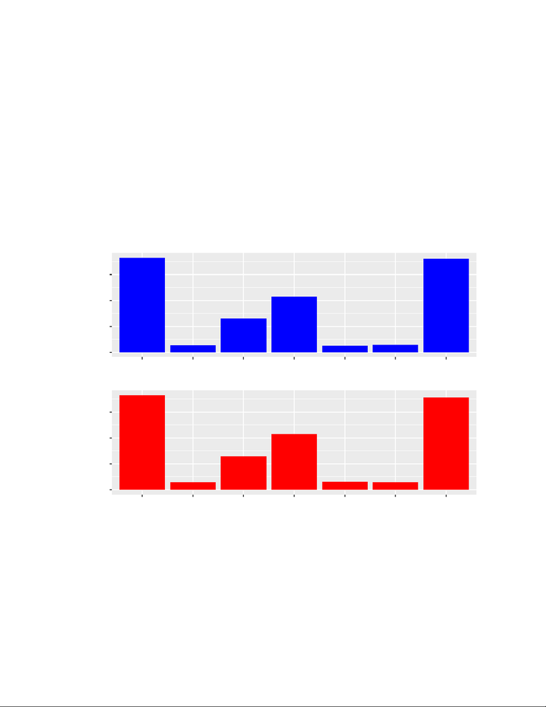

## Detection Rate 0.1852 0.01927 0.02467

## Detection Prevalence 0.1868 0.02239 0.02501

## Balanced Accuracy 0.9972 0.85783 0.99174

## Class: stand+talk

## Sensitivity 0.9949

## Specificity 0.9930

## Pos Pred Value 0.9846

## Neg Pred Value 0.9977

## Prevalence 0.3090

## Detection Rate 0.3075

## Detection Prevalence 0.3123

## Balanced Accuracy 0.9940

As we can see on the confusion matrix, the model looks really great with accuracy over 98 %. We can also

visualize it in histogram form:

0

50000

100000

150000

working stand_walk_down standing walking going_up_down walk+talk stand+talk

Predicted activity

0

50000

100000

150000

working stand_walk_down standing walking going_up_down walk+talk stand+talk

Real activity

Activity comparison

However the 2% diﬀerence is really small so it’s hard to see. But we can ﬁnd out the balanced accuracy in

confusion matrix above.

17

Conclusion

As we can see in the results the random forest performs great on our data with accuracy over 98 %. The

hardest predicted activities are standing up, walking and going up or down stairs; standing; going up or

down stairs. The ﬁrst and last case is quiet understandable to have bad performance because of the changing

movement pattern. However the standing activity should be predicted well, but in this case it could be

misleading because we don’t know if the standing pattern was like standing still or standing while moving

the chest in diﬀerent dimensions.

The model could be improved by setting the kNN and Rf together, however the ranger package creates its

own class and I didn’t found out how connect it. Expect this approach, other machine learning methods

could be used for example deep learning or neural network.

The limitations of our work could be the device and sampling frequency that was used for recording. When

we would ﬁt our model to other devices it could work diﬀerently.

References

Casale, P. Pujol, O. and Radeva, P. ‘Personalization and user veriﬁcation in wearable systems using biometric

walking patterns’ Personal and Ubiquitous Computing, 16(5), 563-580, 2012

https://www.sciencedirect.com/topics/engineering/random-forest

https://nwfsc-timeseries.github.io/atsa-labs/sec-tslab-correlation-within-and-among-time-series.html

18